# PCA Demonstration

RJ Worrall

2026-04-15

## Data Overview

https://www.kaggle.com/datasets/mathchi/covid19-and-character-strengths/data

```r
covid <- read.csv('covid.csv')
dim(covid)
```

```
## [1] 944  41
```

To demonstrate PCA, we will use a dataset tracking psychological responses to the COVID pandemic. This dataset has 944 respondents and 41 variables, perfect for PCA.

## Data Cleaning

To perform PCA, we need to make sure there are no categorical predictors in our dataset, as well as removing and NAs to make sure the analysis isn’t skewed. Additionally, we need to include a correlation matrix to determine linearity of our data (are the predictors linearly correlated with each other).

```r
str(covid)
```

```
## 'data.frame':    944 obs. of  41 variables:
##  $ Participant           : int  1 2 3 4 5 6 7 8 9 10 ...
##  $ Openness              : int  102 96 99 119 127 99 127 103 96 132 ...
##  $ Restraint             : int  51 49 58 68 61 43 62 53 52 64 ...
##  $ Transcendence         : int  116 121 120 131 151 108 113 108 109 123 ...
##  $ Interpersonal         : int  121 100 87 84 97 123 118 121 103 98 ...
##  $ DASS_21               : int  15 18 0 15 37 11 30 29 3 13 ...
##  $ GHQ_12                : int  24 15 7 18 19 14 24 13 15 18 ...
##  $ SEC                   : int  11 20 20 18 14 13 14 14 16 10 ...
##  $ Age                   : int  26 25 26 25 49 22 22 31 27 27 ...
##  $ Gender                : chr  "Female" "Male" "Male" "Female" ...
##  $ Work                  : int  5 1 1 6 5 2 4 2 2 6 ...
##  $ Student               : chr  "Student" "Other" "Other" "Other" ...
##  $ Day                   : int  7 7 7 7 7 7 7 7 7 7 ...
##  $ Sons                  : int  0 0 0 0 1 0 0 0 0 0 ...
```

[output cut: 27 more lines]

```r
covid_clean <- covid %>%
  dplyr::select(where(is.numeric))|>
  select(-Participant)
sum(is.na(covid_clean))
```

```
## [1] 0
```

```r
glimpse(covid_clean)
```

```
## Rows: 944
## Columns: 38
## $ Openness               <int> 102, 96, 99, 119, 127, 99, 127, 103, 96, 132, 1…
## $ Restraint              <int> 51, 49, 58, 68, 61, 43, 62, 53, 52, 64, 51, 60,…
## $ Transcendence          <int> 116, 121, 120, 131, 151, 108, 113, 108, 109, 12…
## $ Interpersonal          <int> 121, 100, 87, 84, 97, 123, 118, 121, 103, 98, 1…
## $ DASS_21                <int> 15, 18, 0, 15, 37, 11, 30, 29, 3, 13, 10, 8, 15…
## $ GHQ_12                 <int> 24, 15, 7, 18, 19, 14, 24, 13, 15, 18, 12, 14, …
## $ SEC                    <int> 11, 20, 20, 18, 14, 13, 14, 14, 16, 10, 12, 17,…
## $ Age                    <int> 26, 25, 26, 25, 49, 22, 22, 31, 27, 27, 25, 23,…
## $ Work                   <int> 5, 1, 1, 6, 5, 2, 4, 2, 2, 6, 1, 3, 6, 6, 5, 3,…
## $ Day                    <int> 7, 7, 7, 7, 7, 7, 7, 7, 7, 7, 7, 7, 7, 7, 7, 7,…
## $ Sons                   <int> 0, 0, 0, 0, 1, 0, 0, 0, 0, 0, 0, 0, 0, 0, 1, 0,…
## $ Appreciation_of_beauty <int> 19, 18, 15, 22, 21, 16, 18, 17, 17, 23, 22, 20,…
## $ Bravery                <int> 17, 16, 16, 15, 18, 15, 22, 18, 16, 20, 18, 16,…
```

[output cut: 25 more lines]

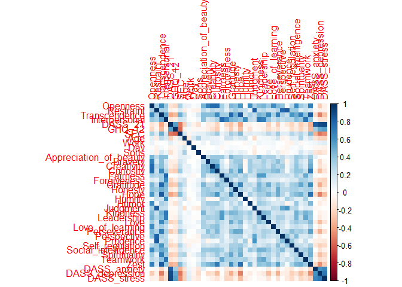

```r
cor_matrix <- cor(covid_clean, use = "complete.obs")

corrplot::corrplot(cor_matrix, method = "color")
```

Most of the variables do have a correlation to each other, meaning that PCA is appropriate for this analysis due to the linearity assumption being confirmed.

## Step 1: Standardization

```r
covid_standard <- scale(covid_clean)
head(covid_standard)
```

```
##        Openness  Restraint Transcendence Interpersonal     DASS_21     GHQ_12
## [1,] -0.5421827 -0.6563114    -0.4466443     0.7649321 -0.00940714  1.4252623
## [2,] -0.9872440 -0.9222161    -0.1659304    -0.9325955  0.27102466 -0.4099951
## [3,] -0.7647134  0.2743551    -0.2220732    -1.9834459 -1.41156614 -2.0413351
## [4,]  0.7188243  1.6038786     0.3954973    -2.2259498 -0.00940714  0.2017574
## [5,]  1.3122394  0.6732121     1.5183526    -1.1750994  2.04709273  0.4056748
## [6,] -0.7647134 -1.7199302    -0.8957864     0.9266014 -0.38331621 -0.6139126
##             SEC        Age       Work        Day       Sons
## [1,] -1.0170411 -0.7752524  0.8409641 -0.9073359 -0.7344354
## [2,]  1.2402163 -0.8442287 -1.7512648 -0.9073359 -0.7344354
## [3,]  1.2402163 -0.7752524 -1.7512648 -0.9073359 -0.7344354
## [4,]  0.7386035 -0.8442287  1.4890213 -0.9073359 -0.7344354
## [5,] -0.2646220  0.8112019  0.8409641 -0.9073359  1.3601478
## [6,] -0.5154284 -1.0511576 -1.1032076 -0.9073359 -0.7344354
##      Appreciation_of_beauty     Bravery Creativity  Curiosity   Fairness
```

[output cut: 41 more lines]

## Step 2: Run preliminary PCA

```r
covid_pca <- prcomp(covid_standard, center = TRUE, scale. = TRUE)
summary(covid_pca)
```

```
## Importance of components:
##                           PC1    PC2     PC3     PC4     PC5     PC6    PC7
## Standard deviation     3.2787 2.0260 1.67795 1.60088 1.24779 1.10420 1.0623
## Proportion of Variance 0.2829 0.1080 0.07409 0.06744 0.04097 0.03209 0.0297
## Cumulative Proportion  0.2829 0.3909 0.46500 0.53244 0.57342 0.60550 0.6352
##                            PC8     PC9    PC10    PC11    PC12    PC13    PC14
## Standard deviation     1.01992 1.01036 0.97708 0.91996 0.91135 0.86104 0.84118
## Proportion of Variance 0.02737 0.02686 0.02512 0.02227 0.02186 0.01951 0.01862
## Cumulative Proportion  0.66258 0.68944 0.71456 0.73683 0.75869 0.77820 0.79682
##                           PC15    PC16    PC17   PC18    PC19    PC20    PC21
## Standard deviation     0.81393 0.77922 0.76862 0.7450 0.72243 0.70154 0.68828
## Proportion of Variance 0.01743 0.01598 0.01555 0.0146 0.01373 0.01295 0.01247
## Cumulative Proportion  0.81426 0.83023 0.84578 0.8604 0.87412 0.88707 0.89954
##                           PC22    PC23    PC24    PC25    PC26    PC27    PC28
## Standard deviation     0.66802 0.63623 0.63286 0.61166 0.58338 0.57621 0.56040
## Proportion of Variance 0.01174 0.01065 0.01054 0.00985 0.00896 0.00874 0.00826
## Cumulative Proportion  0.91128 0.92193 0.93247 0.94232 0.95128 0.96001 0.96828
##                           PC29    PC30   PC31    PC32    PC33      PC34
## Standard deviation     0.53467 0.52275 0.5008 0.46000 0.42883 1.784e-15
## Proportion of Variance 0.00752 0.00719 0.0066 0.00557 0.00484 0.000e+00
## Cumulative Proportion  0.97580 0.98299 0.9896 0.99516 1.00000 1.000e+00
##                             PC35      PC36      PC37      PC38
## Standard deviation     6.501e-16 5.891e-16 3.854e-16 3.664e-16
## Proportion of Variance 0.000e+00 0.000e+00 0.000e+00 0.000e+00
## Cumulative Proportion  1.000e+00 1.000e+00 1.000e+00 1.000e+00
```

## Step 3: Scree Plot

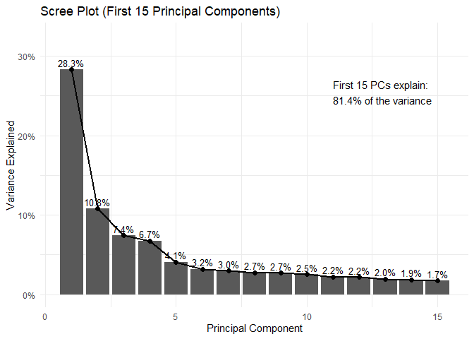

```r
variance <- covid_pca$sdev^2
variance_explained <- variance / sum(variance)

scree_data <- data.frame(
  PC = 1:length(variance_explained),
  Variance = variance_explained
)

# First 15 PCs
scree_15 <- scree_data[1:15, ]

# Total variance explained by first 15 PCs
total_15 <- sum(scree_15$Variance)

ggplot(scree_15, aes(x = PC, y = Variance)) +
  geom_bar(stat = "identity") +

  # Line following tops of bars
  geom_line(linewidth = 1) +
  geom_point(size = 2) +

  # Percent labels on bars
  geom_text(
    aes(label = percent(Variance, accuracy = 0.1)),
    vjust = -0.4,
    size = 3.5
  ) +

  # Annotation in empty space
  annotate(
    "text",
    x = 11,
    y = max(scree_15$Variance) * 0.9,
    label = paste0(
      "First 15 PCs explain:\n",
      percent(total_15, accuracy = 0.1), ' of the variance'
    ),
    hjust = 0,
    size = 4
  ) +

  scale_y_continuous(
    labels = percent_format(accuracy = 1),
    limits = c(0, max(scree_15$Variance) * 1.15)
  ) +

  labs(
    title = "Scree Plot (First 15 Principal Components)",
    x = "Principal Component",
    y = "Variance Explained"
  ) +

  theme_minimal()
```

## Step 4: Extract Principal Components

```r
covid_scores <- covid_pca$x
head(covid_scores)
```

```
##             PC1        PC2        PC3         PC4        PC5        PC6
## [1,] -1.1202858  0.7515730  0.8310717 -1.98868529 -1.4243198 -0.5142418
## [2,] -2.8217514 -1.5704074 -0.4378691  0.04275032  0.3895735 -1.4117443
## [3,] -2.4504113 -4.2530158  0.4594933  3.62940742 -0.6518325 -1.4832627
## [4,]  0.7344338  0.1975936 -1.7669750  5.29584731  1.0847138 -1.1892484
## [5,]  1.6228417  2.0509672 -3.2201235  1.97931737  5.1876109 -0.3615827
## [6,] -2.2480281 -0.9524503  1.1428659 -2.97060371 -2.5232758 -0.4891607
##             PC7        PC8        PC9       PC10        PC11      PC12
## [1,] -0.7484202 -0.9076051 -1.1085038 -0.1940108 -0.38770679 -1.777124
## [2,] -0.7943927  1.9977741 -1.0061023 -1.1953446  0.04758846  0.494380
## [3,] -0.6671367  1.6065989  0.2472796 -1.3455936  0.74377037  1.415366
## [4,] -1.9598300 -1.5774978 -1.0043826  0.6421102  0.24917065 -1.694722
## [5,] -1.5194389 -0.4188712 -2.2182133 -0.0610974  0.17763251  1.567663
## [6,]  0.8475383  1.2475038 -0.4216912 -0.7231198  0.10625703  0.289493
##             PC13        PC14       PC15       PC16       PC17        PC18
```

[output cut: 34 more lines]

## Step 5: Statistcal Mehods for Choosing Principal Components

Kaiser Criteria selects principal components based on if their eigenvalues are greater than 1, indicating significance/more variance accounted for than any subsequent components.

```r
# Kaiser Criteria
eigenvalues <- covid_pca$sdev^2

which(eigenvalues > 1)
```

```
## [1] 1 2 3 4 5 6 7 8 9
```

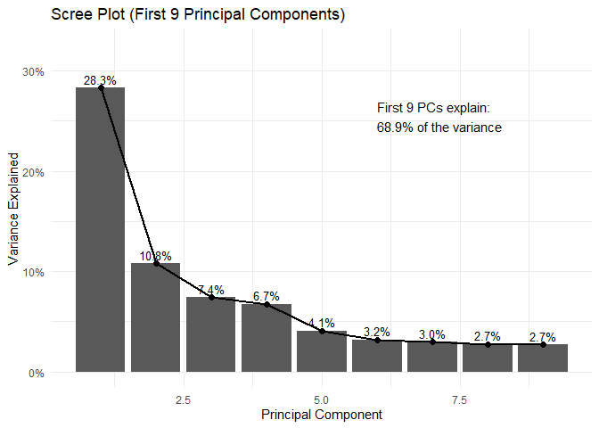

```r
# First 19 PCs
scree_15 <- scree_data[1:9, ]

# Total variance explained by first 9 PCs
total_15 <- sum(scree_15$Variance)

ggplot(scree_15, aes(x = PC, y = Variance)) +
  geom_bar(stat = "identity") +

  # Line following tops of bars
  geom_line(linewidth = 1) +
  geom_point(size = 2) +

  # Percent labels on bars
  geom_text(
    aes(label = percent(Variance, accuracy = 0.1)),
    vjust = -0.4,
    size = 3.5
  ) +

  # Annotation in empty space
  annotate(
    "text",
    x = 6,
    y = max(scree_15$Variance) * 0.9,
    label = paste0(
      "First 9 PCs explain:\n",
      percent(total_15, accuracy = 0.1), ' of the variance'
    ),
    hjust = 0,
    size = 4
  ) +

  scale_y_continuous(
    labels = percent_format(accuracy = 1),
    limits = c(0, max(scree_15$Variance) * 1.15)
  ) +

  labs(
    title = "Scree Plot (First 9 Principal Components)",
    x = "Principal Component",
    y = "Variance Explained"
  ) +

  theme_minimal()
```

Parallel analysis is widely considered as one of the best methods to find the optimal number of PCS, which it does by generating random datasets of the same dimensions, and keeps the principal components if their eigenvalues are higher than the eigenvalues of the randomly generated datasets, which is done in order to avoid over-retention of principal components.

```r
# Parallel Analysis
fa.parallel(covid_standard, fa = "pc", n.iter = 100)
```

```
## In smc, smcs < 0 were set to .0
## In smc, smcs < 0 were set to .0
## In smc, smcs < 0 were set to .0
```

```
## In factor.scores, the correlation matrix is singular, the pseudo inverse is  used
```

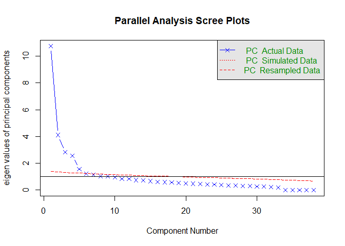

```
## Parallel analysis suggests that the number of factors =  NA  and the number of components =  5
```

Parallel analysis selects only 5 principal components. The interpretation of these results is that the first 5 principal components are capturing the majority of the real structure of the data, whereas PC6 onwards mostly captures noise.

## Step 6: Choosing Optimal Number of PCS

```r
cat('Kaiser Criteria Optimal Number of Components:',sum(eigenvalues > 1))
```

```
## Kaiser Criteria Optimal Number of Components: 9
```

```r
cat('\nParallel Analysis Optimal Number of Components: 5')
```

```
##
## Parallel Analysis Optimal Number of Components: 5
```

```r
cat('\nScree Plot Optimal Number of Components: 6')
```

```
##
## Scree Plot Optimal Number of Components: 6
```

Our choice for the optimal number of components is different for each model, so how do we pick the right one? Among experts, Parallel Analysis is the most trusted method for picking the optimal number of components, with the Kaiser criteria following behind it. Because the results from our Scree plot earlier are very close to the results of the Parallel Analysis, we choose 6 as our optimal number of components, as 5 might be a bit too few based on the scree plot from the parallel analysis.

## Step 7: Exploring Chosen Components

Now that we have identified our optimal number of principal components, we can explore what exactly are the most important features of the dataset.

```r
covid_reduced <- covid_scores[,1:6]
loadings_6 <- covid_pca$rotation[, 1:6]

# Function to extract top 10 variables per PC
top_6 <- lapply(1:6, function(i) {
  vals <- loadings_6[order(abs(loadings_6[, i]), decreasing = TRUE)[1:10], i]
  data.frame(
    PC = paste0("PC", i),
    Variable = names(vals),
    Coefficient = vals
  )
})

top_6_table <- do.call(rbind, top_6)

top_6_table
```

```
##                      PC            Variable Coefficient
## Transcendence       PC1       Transcendence   0.2754267
## Zest                PC1                Zest   0.2409450
## Openness            PC1            Openness   0.2406979
## Hope                PC1                Hope   0.2342591
## Gratitude           PC1           Gratitude   0.2196852
## Curiosity           PC1           Curiosity   0.2136135
## Interpersonal       PC1       Interpersonal   0.2121517
## Social_intelligence PC1 Social_intelligence   0.1927756
## Perseverance        PC1        Perseverance   0.1911254
## Kindness            PC1            Kindness   0.1839385
## DASS_21             PC2             DASS_21   0.4004829
## DASS_stress         PC2         DASS_stress   0.3641938
## DASS_depression     PC2     DASS_depression   0.3533943
## DASS_anxiety        PC2        DASS_anxiety   0.3355267
## GHQ_12              PC2              GHQ_12   0.2681261
## SEC                 PC2                 SEC  -0.2291955
## Fairness            PC2            Fairness   0.1813242
## Restraint           PC2           Restraint   0.1792547
## Judgment            PC2            Judgment   0.1770154
## Perspective         PC2         Perspective   0.1630127
## Prudence            PC3            Prudence   0.3804737
## Humilty             PC3             Humilty   0.3244482
## Openness1           PC3            Openness  -0.2863893
## Restraint1          PC3           Restraint   0.2677824
## Bravery             PC3             Bravery  -0.2552421
## Creativity          PC3          Creativity  -0.2471859
## Curiosity1          PC3           Curiosity  -0.2434429
## Interpersonal1      PC3       Interpersonal   0.2363342
## Humor               PC3               Humor  -0.2129211
## Zest1               PC3                Zest  -0.1911605
## Restraint2          PC4           Restraint   0.3838983
## Judgment1           PC4            Judgment   0.3700533
## Perspective1        PC4         Perspective   0.3100709
## Interpersonal2      PC4       Interpersonal  -0.2976478
## Prudence1           PC4            Prudence   0.2768961
## Forgiveness         PC4         Forgiveness  -0.2508863
## Teamwork            PC4            Teamwork  -0.2269837
## Fairness1           PC4            Fairness  -0.2191365
## Kindness1           PC4            Kindness  -0.2161778
## Age                 PC4                 Age  -0.1939593
## Age1                PC5                 Age   0.3751969
## Humor1              PC5               Humor  -0.2956638
## Sons                PC5                Sons   0.2789114
## Spirituality        PC5        Spirituality   0.2714955
## Perseverance1       PC5        Perseverance   0.2569817
## Self_regulation     PC5     Self_regulation   0.2535332
## Transcendence1      PC5       Transcendence   0.2170403
## Leadership          PC5          Leadership  -0.2140194
## Fairness2           PC5            Fairness  -0.1980264
## DASS_anxiety1       PC5        DASS_anxiety   0.1954303
## Age2                PC6                 Age   0.3963840
## Love                PC6                Love  -0.3767105
## Love_of_learning    PC6    Love_of_learning   0.3322155
## Day                 PC6                 Day   0.2797612
## Gratitude1          PC6           Gratitude  -0.2620304
## Transcendence2      PC6       Transcendence  -0.2408386
## Creativity1         PC6          Creativity   0.2278480
## Sons1               PC6                Sons   0.2183106
## Openness2           PC6            Openness   0.2020967
## Hope1               PC6                Hope  -0.1995810
```

Now that we have mapped out each principal component and the weights of the variables within them, lets look a bit deeper into PC1 and PC2 to determine their significance in the context of the data.

```r
pc1_vals <- loadings_6[order(abs(loadings_6[,1]), decreasing = TRUE)[1:10], 1]

pc1_table <- data.frame(
  Variable = names(pc1_vals),
  Coefficient = pc1_vals
)

pc1_table
```

```
##                                Variable Coefficient
## Transcendence             Transcendence   0.2754267
## Zest                               Zest   0.2409450
## Openness                       Openness   0.2406979
## Hope                               Hope   0.2342591
## Gratitude                     Gratitude   0.2196852
## Curiosity                     Curiosity   0.2136135
## Interpersonal             Interpersonal   0.2121517
## Social_intelligence Social_intelligence   0.1927756
## Perseverance               Perseverance   0.1911254
## Kindness                       Kindness   0.1839385
```

Looking at the data, we notice that the top 10 variables in the first principal component are all positive psychological and social traits. This tells us, that because this was chosen as the first principal component, that the largest variation in the data comes from the positive traits, meaning there is a lot of variation in positive psychological functioning among respondents during the COVID period. To increase the interpretability of our data, we can label PC1 as Positive Well-Being.

```r
pc2_vals <- loadings_6[order(abs(loadings_6[,2]), decreasing = TRUE)[1:10], 2]

pc2_table <- data.frame(
  Variable = names(pc2_vals),
  Coefficient = pc2_vals
)

pc2_table
```

```
##                        Variable Coefficient
## DASS_21                 DASS_21   0.4004829
## DASS_stress         DASS_stress   0.3641938
## DASS_depression DASS_depression   0.3533943
## DASS_anxiety       DASS_anxiety   0.3355267
## GHQ_12                   GHQ_12   0.2681261
## SEC                         SEC  -0.2291955
## Fairness               Fairness   0.1813242
## Restraint             Restraint   0.1792547
## Judgment               Judgment   0.1770154
## Perspective         Perspective   0.1630127
```

As opposed to the positivity of PC1, the second principal component captures much more negative feelings as the most significant variables. This makes sense in context, as PC2 is orthogonal, or uncorrelated with PC1, capturing a whole new part of the data. Because it wasn’t chosen as PC1, PC2 isn’t the primary source of variation in the data, and thus forms a secondary but distinct dimension of variation. We can label this component as Mental Health Strain for interpretability.

So, what does this tell us about our data? While the 2 components capture very different information, it is important to understand that they aren’t complete opposites. A person could be high in some of the positive categories, but still have anxiety about the pandemic. This is why PCA is so helpful, is because it combines these correlated positive and negative variables respectively together in their own smaller dimensions, so we can clearly visualize and understand the trends between them!

## Step 8: Visualization

Now that our principal components are chosen and interpreted, we can use the reduced data for modeling, visualization, and a variety of other tasks.

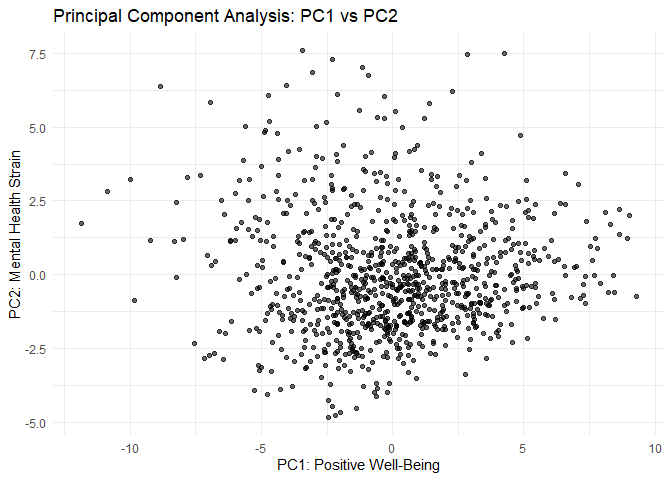

```r
pc_plot_data <- as.data.frame(covid_scores[, 1:2])

colnames(pc_plot_data) <- c("PC1_Positive_WellBeing",
                            "PC2_Mental_Health_Strain")

ggplot(pc_plot_data, aes(x = PC1_Positive_WellBeing,
                         y = PC2_Mental_Health_Strain)) +
  geom_point(alpha = 0.6) +
  labs(
    title = "Principal Component Analysis: PC1 vs PC2",
    x = "PC1: Positive Well-Being",
    y = "PC2: Mental Health Strain"
  ) +
  theme_minimal()
```